# Assignment 4: Clustering and classification

## LDA with clusters as target classes

Next, we will fit and LDA model to the scaled Boston data using clusters from k-means clustering as target classes. We will first run the k-means algorithm (this time for 3 clusters), then include the cluster labels in our scaled data set, and then fit LDA with clusters as the target classes and all other variables as predictors. Finally, we will visualize the results with a biplot.

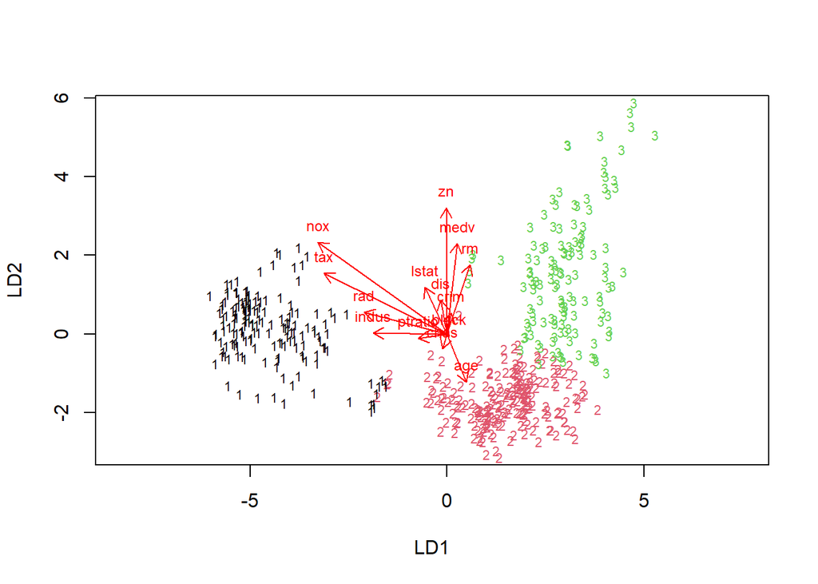

```r
# reload the data, not strictly necessary as there were no changes to this data frame previously
data("Boston")

# setting seed for replicability
set.seed(1)

# standardizing the data set and changing to data frame
boston_scaled <- as.data.frame(scale(Boston))

# k-means clustering with 3 clusters
km <- kmeans(boston_scaled, centers = 3)

# include clusters in the boston data frame
boston_scaled$cluster <- km$cluster

# fit linear discriminant analysis
lda.fit <- lda(cluster ~ ., data = boston_scaled)

# the function for lda biplot arrows
lda.arrows <- function(x, myscale = 1, arrow_heads = 0.1, color = "red", tex = 0.75, choices = c(1,2)){
  heads <- coef(x)
  arrows(x0 = 0, y0 = 0,
         x1 = myscale * heads[,choices[1]],
         y1 = myscale * heads[,choices[2]], col=color, length = arrow_heads)
  text(myscale * heads[,choices], labels = row.names(heads),
       cex = tex, col=color, pos=3)
}

# target classes as numeric
classes <- as.numeric(boston_scaled$cluster)

# plot the lda results
plot(lda.fit, dimen = 2, col = classes, pch = classes)
lda.arrows(lda.fit, myscale = 3)
```

The three clusters are quite well separated in the biplot. Looking at the arrows for variables in the biplot, we can see that to discriminate cluster one from the other two, variables nox, tax, rad and indus seem most significant. This is fairly similar to what we could tell from the scatterplot matrix for the two clusters in the previous section. We can also see that the variable age (proportion of owner-occupied units built prior to 1940) seems to be most significant in separating cluster two from the others, and that variables zn (proportion of residential land zoned for lots over 25,000 sq.ft), medv (median value of owner-occupied homes in $1000s) and rm (average number of rooms per dwelling) seem to be most significant in separating cluster three from the other two. Cluster number three seems to be connected to size of accommodation, while cluster number two seems to relate to age of housing.

```
## [1] "Last updated Tue Nov 29 01:52:56 2022"
```